# Causal Analysis of Physical Activity on BMI using NHANES Data

Sandani Kumanayake

2024-06-04

## Introduction and Data Description

The National Health and Nutrition Examination Survey (NHANES), conducted by the U.S. National Center for Health Statistics (NCHS), is an invaluable resource for assessing the health and nutritional status of the American population. Starting in the 1960s, NHANES has been pivotal in providing data that guide public health policies and medical guidelines. The 2009-2012 NHANES dataset, specifically its raw version (NHANESraw), is utilized in this study. It offers a detailed and representative cross-sectional view of the non-institutionalized civilian resident population of the United States.

NHANESraw is distinct for its comprehensive coverage of health, nutritional, and demographic variables. It uses a complex survey design that includes oversampling of specific subpopulations, like racial minorities, to ensure their adequate representation. This design complexity requires rigorous analytical approaches to avoid biased conclusions.

In this analysis for Additional Requirements 690C, I am taking into account the survey design and also imputing missing values for the outcome variable.

## Objective

This study aims to determine the causal impact of physical activity on Body Mass Index (BMI) among the U.S. population, using the NHANESraw 2009-2012 dataset. The analysis employs the backdoor criterion for causal inference while controlling for potential confounders and the intricate survey design inherent in NHANES.

## Data Preparation

For this analysis, I am considering six potential confounders - a variable that could affect both the treatment and the outcome. First, let’s examine the types of the variables of interest in the NHANES raw dataset.

-PhysActive (Treatment): A binary factor variable indicating the physical activity status of individuals, categorized as ‘Yes’ or ‘No’.  
-BMI (Outcome): Representing the Body Mass Index, a numerical measure calculated from weight and height.  
-Age (Integer): Age, recorded in years, is a fundamental demographic variable.  
-Gender (Factor): Categorized as ‘female’ or ‘male’.  
-Race1 (Factor): This variable, with categories like ‘Black’, ‘Hispanic’, etc., reflects the racial diversity of the dataset.  
-Education (Factor): With levels indicating educational attainment, such as ‘8th Grade’, ‘High School’, ‘College Grad’, etc.  
-HHIncome (Factor): Representing household income in various brackets.  
-MaritalStatus (Factor): Including categories like ‘Married’, ‘Divorced’, ‘Single’, etc.

## Potential Outcomes and Their Interpretation

In the context of this study, the potential outcomes refer to the different Body Mass Index (BMI) levels that individuals in the NHANES dataset might have under varying scenarios of physical activity. Specifically, the two key potential outcomes are: 1) the BMI level of an individual if they engage in regular physical activity, and 2) the BMI level of the same individual if they do not engage in physical activity. These outcomes allow us to compare the BMI levels across these two scenarios, thus providing insight into the effect of physical activity on BMI.

## Causal Estimand(s) of Interest and Their Interpretations

The primary causal estimand in this analysis is the average treatment effect (ATE) of physical activity on BMI. This refers to the average difference in BMI between the two potential outcomes: when individuals are physically active versus when they are not. The interpretation of this ATE is pivotal as it quantifies the expected change in BMI that could be attributed to physical activity. If the ATE is significantly negative, it implies that engaging in physical activity is associated with a lower BMI on average, suggesting potential health benefits of being physically active.

## Checking for Duplicates in the Dataset

An essential step in data preparation is to ensure the uniqueness of each observation. Duplicates can skew the analysis and lead to misleading conclusions. Therefore, a thorough check for duplicate rows in the NHANESraw dataset was conducted.

```
## Total Rows in the Dataset: 20293
```

```
## Unique Rows in the Dataset: 20293
```

The results indicate that there are no duplicate rows in the NHANESraw dataset. Each row represents a unique observation, which is crucial for maintaining the accuracy of the analysis.

## Handling Missing Data

In the next phase of data preparation for the NHANESraw dataset, I address the issue of missing values in key variables. Proper handling of missing data is critical for the robustness of the analysis, as missing values can introduce bias and potentially invalidate the results.

An assessment of missing values in the NHANESraw dataset was conducted for the selected variables.

```
##    PhysActive           BMI           Age        Gender         Race1
##          6015          2279             0             0             0
##     Education      HHIncome MaritalStatus
##          8535          2076          8526
```

Given the nature of the NHANESraw dataset, a strategic approach to handle missing values is implemented:

BMI (Outcome Variable): Special attention is given to handling missing values in BMI. Given its importance as the outcome variable, an imputation strategy, such as median imputation, will be employed. This approach is justified by the need to maintain a complete dataset for a robust analysis of the outcome.

PhysActive (Treatment) and Confounders: For the treatment variable (PhysActive) and other confounders (Age, Gender, Race1, Education, HHIncome, MaritalStatus), listwise deletion will be utilized. Records with missing values in these variables will be excluded from the analysis. This decision is based on the principle of maintaining data integrity for variables directly influencing the treatment and confounders in the causal model.

## Descriptive Analysis

After addressing the missing values in the dataset, the next step in the analysis involves creating visualizations for the key variables. These visualizations are important for understanding the distribution and characteristics of the data, particularly focusing on non missing values to ensure accuracy.

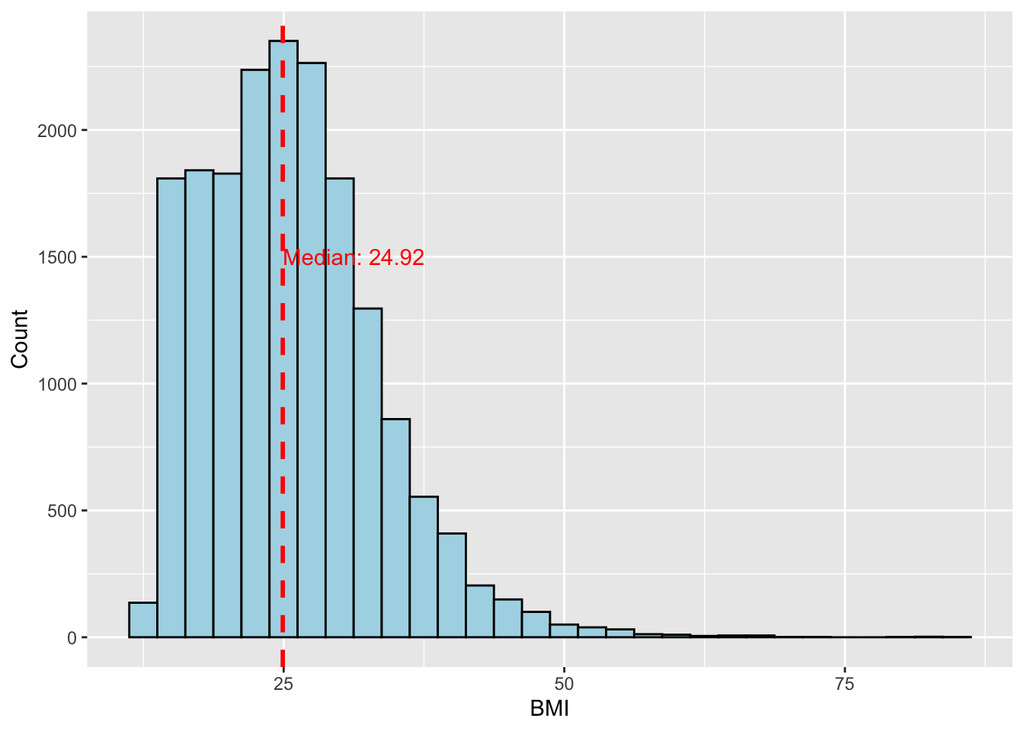

Histogram of BMI (Non-Missing Values)

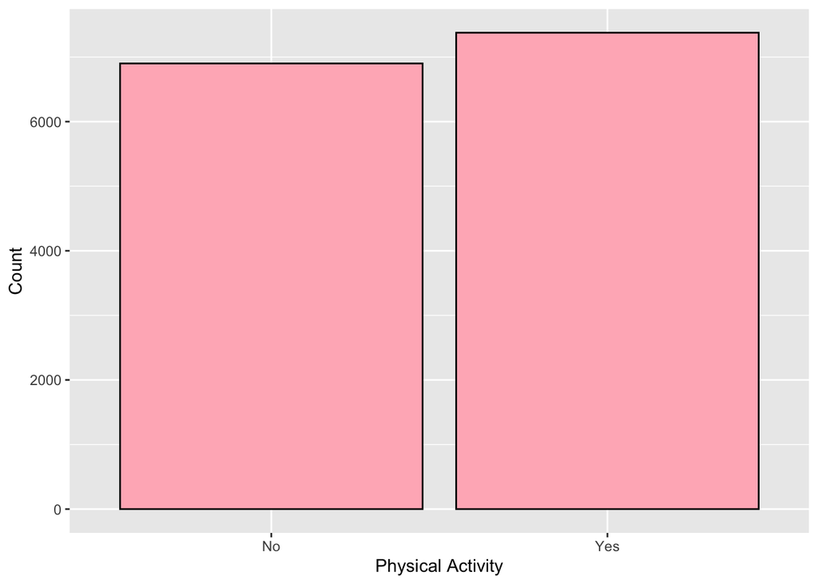

Bar Plot of Physical Activity (Non-Missing Values)

According to the bar chart (Figure 02), a slightly higher proportion of individuals in the dataset engage in physical activity compared to those who do not. While this difference is noticeable, it is not markedly substantial, indicating a relatively balanced distribution of physical activity status among the participants.

## Causal Analysis

**Identification Conditions of the Causal Model**

The causal inference relies on several key assumptions:

1. Stable Unit Treatment Value Assumption (SUTVA): This assumption posits that the potential outcome for any individual is unaffected by the treatment status of others. In this context, it implies that an individual’s BMI is influenced solely by their physical activity level, independent of others’ activity levels.
2. Positivity: This condition assumes that every individual in the population has a non zero probability of experiencing each treatment level. For this study, this translates to all individuals having some chance of being physically active or inactive.
3. Consistency: Under this assumption, the potential outcome of an individual under the treatment they receive is equal to the observed outcome. In simpler terms, if an individual is observed as physically active, their BMI corresponds to this state of activity.
4. No Unobserved Confounding: This assumption suggests that all confounders affecting both the treatment (physical activity) and the outcome (BMI) are observed and accounted for in the model. This assumption is critical for asserting that the observed differences in BMI are due to physical activity levels and not other unmeasured factors.

**Assessment of Identification Conditions**

SUTVA is generally reasonable in observational studies like NHANES, where individual outcomes (BMI levels) are not likely to be directly influenced by others’ physical activity levels. Positivity is a plausible assumption in our analysis, given the diverse representation of physical activity levels across various demographic groups. Consistency is maintained, as physical activity is a well defined and measurable exposure in NHANES.

The potential for unobserved confounding exists, especially considering factors like genetic predispositions or unrecorded lifestyle habits that might influence both physical activity and BMI. While my model accounts for many known confounders, the possibility of residual confounding cannot be entirely ruled out.

**Statistical Estimands and Estimator**

The primary estimand in this study is the average treatment effect of physical activity on BMI, adjusting for age, gender, race, education, income and Marital Status. The aim is to estimate the difference in mean BMI between individuals who are physically active and those who are not.

The estimator employed is a survey weighted regression model. This model inherently assumes linearity in parameters and that the residuals are normally distributed. I also assume that observations are independent within each cluster defined by the survey’s complex design. This approach allows to accurately reflect the NHANES sampling strategy and provide unbiased estimates that are representative of the U.S. population.

**Initial Model Analysis (Without BMI Imputation)**

The initial model aims to assess the relationship between physical activity and BMI while accounting for confounders such as age, gender, race, education, income and Marital Status. This model is based on the NHANES dataset with unique entries and no imputation for missing BMI values.

Defining the Survey Design:

-I defined the survey design using the svydesign function. This step involved specifying the primary sampling units (PSUs), strata, and survey weights.  
-ids = ~SDMVPSU: The ids argument denotes the clustering within the dataset, with SDMVPSU representing the cluster variable.  
-strata = ~SDMVSTRA: The strata argument helps in acknowledging the stratified sampling design, with SDMVSTRA being the stratification variable.  
-weights = ~WTMEC2YR: The weights argument incorporates the sampling weights (WTMEC2YR).  
-nest = TRUE: This parameter is set to account for the nesting of clusters within strata.

Survey Weighted Regression Model:

After establishing the survey design, I conducted a survey weighted regression analysis using the svyglm function. This approach allows for the estimation of relationships between variables while respecting the survey’s complex design.

```
##
## Call:
## svyglm(formula = BMI ~ PhysActive + Age + Gender + Race1 + Education +
##     HHIncome + MaritalStatus, design = nhanes_design)
##
## Survey design:
## svydesign(ids = ~SDMVPSU, strata = ~SDMVSTRA, weights = ~WTMEC2YR,
##     data = NHANESraw, nest = TRUE)
##
## Coefficients:
##                            Estimate Std. Error t value Pr(>|t|)
## (Intercept)               30.945811   0.853164  36.272 2.93e-08 ***
## PhysActiveYes             -1.347517   0.212742  -6.334 0.000725 ***
## Age                        0.014733   0.006702   2.198 0.070274 .
## Gendermale                -0.010540   0.133521  -0.079 0.939646
## Race1Hispanic             -2.165946   0.328682  -6.590 0.000587 ***
## Race1Mexican              -1.522003   0.367859  -4.137 0.006096 **
## Race1White                -2.568737   0.298429  -8.608 0.000135 ***
## Race1Other                -4.633499   0.362880 -12.769 1.42e-05 ***
## Education9 - 11th Grade    0.058326   0.332593   0.175 0.866558
## EducationHigh School       0.672219   0.311630   2.157 0.074373 .
## EducationSome College      0.809490   0.267883   3.022 0.023343 *
## EducationCollege Grad     -0.265851   0.366999  -0.724 0.496089
## HHIncome10000-14999        0.721083   0.594063   1.214 0.270425
## HHIncome15000-19999        0.645450   0.607961   1.062 0.329242
## HHIncome20000-24999        0.730401   0.635457   1.149 0.294133
## HHIncome25000-34999        0.929418   0.660835   1.406 0.209219
## HHIncome35000-44999        0.287628   0.563528   0.510 0.627995
## HHIncome45000-54999        0.248743   0.629534   0.395 0.706417
## HHIncome5000-9999          0.260061   0.563103   0.462 0.660470
## HHIncome55000-64999        0.127118   0.690512   0.184 0.860005
## HHIncome65000-74999        1.406634   0.841466   1.672 0.145626
## HHIncome75000-99999        0.448351   0.747287   0.600 0.570474
## HHIncomemore 99999        -0.376329   0.629216  -0.598 0.571648
## MaritalStatusLivePartner  -0.831417   0.429298  -1.937 0.100904
## MaritalStatusMarried      -0.160926   0.308545  -0.522 0.620659
## MaritalStatusNeverMarried -1.244754   0.352678  -3.529 0.012376 *
## MaritalStatusSeparated    -0.720419   0.515805  -1.397 0.211986
## MaritalStatusWidowed      -0.928892   0.403148  -2.304 0.060758 .
## ---
## Signif. codes:  0 '***' 0.001 '**' 0.01 '*' 0.05 '.' 0.1 ' ' 1
##
## (Dispersion parameter for gaussian family taken to be 56.39504)
##
## Number of Fisher Scoring iterations: 2
```

```
## Coefficient for Physical Activity (PhysActiveYes): -1.347517
```

```
## 95% Confidence Interval for Physical Activity (PhysActiveYes): [ -1.764492 , -0.930542 ]
```

Physical Activity (PhysActiveYes): The coefficient for physical activity is -1.3, with a 95% confidence interval of [-1.8, -0.9]. This result indicates a statistically significant negative association between physical activity and BMI. It implies that, on average, individuals who are physically active have a lower BMI compared to those who are not active, with the estimated difference in BMI being about 1.3 units lower for physically active individuals. This finding aligns with the general understanding that physical activity can contribute to a healthier BMI.

**Model with Imputed BMI**

In order to accommodate for the missing BMI values in the NHANESraw dataset, I employed median imputation. This approach is particularly appropriate given the right skewed distribution of BMI, where the median serves as a more representative measure of central tendency than the mean.

The survey design and the Survey Weighted Regression Model remained same as the initial model.

```
##
## Call:
## svyglm(formula = BMI ~ PhysActive + Age + Gender + Race1 + Education +
##     HHIncome + MaritalStatus, design = nhanes_design_imputed)
##
## Survey design:
## svydesign(ids = ~SDMVPSU, strata = ~SDMVSTRA, weights = ~WTMEC2YR,
##     data = NHANES_imputed, nest = TRUE)
##
## Coefficients:
##                            Estimate Std. Error t value Pr(>|t|)
## (Intercept)               30.975124   0.864188  35.843 3.14e-08 ***
## PhysActiveYes             -1.311896   0.208680  -6.287 0.000754 ***
## Age                        0.013082   0.006618   1.977 0.095459 .
## Gendermale                -0.018841   0.134163  -0.140 0.892912
## Race1Hispanic             -2.126581   0.332790  -6.390 0.000691 ***
## Race1Mexican              -1.526423   0.365525  -4.176 0.005840 **
## Race1White                -2.564207   0.297946  -8.606 0.000135 ***
## Race1Other                -4.603946   0.361900 -12.722 1.45e-05 ***
## Education9 - 11th Grade    0.061280   0.332070   0.185 0.859669
## EducationHigh School       0.675244   0.308414   2.189 0.071133 .
## EducationSome College      0.798156   0.262766   3.038 0.022876 *
## EducationCollege Grad     -0.263808   0.358061  -0.737 0.489060
## HHIncome10000-14999        0.677593   0.575193   1.178 0.283388
## HHIncome15000-19999        0.665642   0.612424   1.087 0.318806
## HHIncome20000-24999        0.706436   0.626280   1.128 0.302401
## HHIncome25000-34999        0.912670   0.663526   1.375 0.218125
## HHIncome35000-44999        0.290628   0.561055   0.518 0.622995
## HHIncome45000-54999        0.290351   0.632748   0.459 0.662479
## HHIncome5000-9999          0.207776   0.557994   0.372 0.722421
## HHIncome55000-64999        0.168040   0.689605   0.244 0.815599
## HHIncome65000-74999        1.437543   0.839549   1.712 0.137685
## HHIncome75000-99999        0.473151   0.743619   0.636 0.548082
## HHIncomemore 99999        -0.355184   0.627484  -0.566 0.591889
## MaritalStatusLivePartner  -0.857835   0.432375  -1.984 0.094498 .
## MaritalStatusMarried      -0.181103   0.312664  -0.579 0.583513
## MaritalStatusNeverMarried -1.275978   0.353113  -3.614 0.011184 *
## MaritalStatusSeparated    -0.786336   0.520164  -1.512 0.181362
## MaritalStatusWidowed      -0.975445   0.398248  -2.449 0.049835 *
## ---
## Signif. codes:  0 '***' 0.001 '**' 0.01 '*' 0.05 '.' 0.1 ' ' 1
##
## (Dispersion parameter for gaussian family taken to be 54.31049)
##
## Number of Fisher Scoring iterations: 2
```

```
## Coefficient for Physical Activity (PhysActiveYes) in Imputed Model: -1.311896
```

```
## 95% Confidence Interval for Physical Activity (PhysActiveYes) in Imputed Model: [ -1.72091 , -0.9028826 ]
```

This enhanced model similarly demonstrated a significant negative relationship between physical activity and BMI. The findings are consistent with the initial model, suggesting a robust association.

## Comparative Analysis and Conclusions

The comparison of the initial and imputed models shows consistency in the primary findings. Physical activity maintains a negative association with BMI across both models.

This study underscores the potential benefits of physical activity in managing BMI and provides insights into the impact of demographic, socio-economic, and marital factors on BMI. It is important to note, however, that the observational nature of the analysis limits our ability to establish definitive causality. Future studies using longitudinal or experimental designs could provide a more detailed understanding of these relationships.

## R Code Appendix

```r
data("NHANESraw")

# Check the number of unique rows in the dataset
n_distinct_rows <- NHANESraw %>%
  distinct() %>%
  nrow()

# Compare the number of distinct rows with the total number of rows
total_rows <- nrow(NHANESraw)
unique_rows <- n_distinct_rows

# Print the comparison
cat("Total Rows in the Dataset:", total_rows, "\n")
cat("Unique Rows in the Dataset:", unique_rows, "\n")

# Check for Missing values
selected_vars <- c("PhysActive", "BMI", "Age", "Gender", "Race1",
                   "Education", "HHIncome", "MaritalStatus")
missing_values_selected <- sapply(NHANESraw[selected_vars],
                                  function(x) sum(is.na(x)))
missing_values_selected

# Calculate the median of BMI
median_BMI <- median(NHANESraw$BMI, na.rm = TRUE)

# Histogram for BMI (non-missing values) with a median line
ggplot(NHANESraw %>% filter(!is.na(BMI)), aes(x = BMI)) +
  geom_histogram(bins = 30, fill = "lightblue", color = "black") +
  geom_vline(aes(xintercept = median_BMI), color = "red",
             linetype = "dashed", size = 1) +
  xlab("BMI") + ylab("Count") +
  annotate("text", x = median_BMI, y = 1500, label =
             paste("Median:", round(median_BMI, 2)), hjust = 0, color = "red")

# Bar plot for PhysActive (non-missing values)
ggplot(NHANESraw %>% filter(!is.na(PhysActive)), aes(x = PhysActive)) +
  geom_bar(fill = "lightpink", color = "black") +
  xlab("Physical Activity") + ylab("Count")

####Model 01
# Initial model without imputation
# Define the survey design with nested clusters
nhanes_design <- svydesign(ids = ~SDMVPSU, strata = ~SDMVSTRA,
                           weights = ~WTMEC2YR, data = NHANESraw, nest = TRUE)

# Fit a survey-weighted regression model
model_survey <- svyglm(BMI ~ PhysActive + Age + Gender + Race1 +
                         Education + HHIncome + MaritalStatus, design = nhanes_design)
summary(model_survey)

# Extracting the coefficient and standard error for PhysActiveYes
coef_info <- coef(summary(model_survey))
phys_active_coef <- coef_info["PhysActiveYes", "Estimate"]
phys_active_se <- coef_info["PhysActiveYes", "Std. Error"]

# Calculating 95% confidence interval
ci_lower <- phys_active_coef - 1.96 * phys_active_se
ci_upper <- phys_active_coef + 1.96 * phys_active_se

# Printing the coefficient and confidence interval
cat("Coefficient for Physical Activity (PhysActiveYes):", phys_active_coef, "\n")
cat("95% Confidence Interval for Physical Activity (PhysActiveYes):
    [", ci_lower, ",", ci_upper, "]\n")

####Model 02
# Preparing data with imputed BMI
NHANES_imputed <- NHANESraw
NHANES_imputed$BMI <- ifelse(is.na(NHANES_imputed$BMI),
                             median(NHANES_imputed$BMI,
                             na.rm = TRUE), NHANES_imputed$BMI)

# Define the survey design with nested clusters for the imputed dataset
nhanes_design_imputed <- svydesign(ids = ~SDMVPSU, strata = ~SDMVSTRA,
                                   weights = ~WTMEC2YR, data = NHANES_imputed,
                                   nest = TRUE)

# Fit a survey-weighted regression model with imputed BMI and additional confounders
model_survey_imputed <- svyglm(BMI ~ PhysActive + Age + Gender + Race1 +
                                 Education + HHIncome + MaritalStatus,
                               design = nhanes_design_imputed)
summary(model_survey_imputed)

# Extracting the coefficient and standard error for PhysActiveYes from the imputed model
coef_info_imputed <- coef(summary(model_survey_imputed))
phys_active_coef_imputed <- coef_info_imputed["PhysActiveYes", "Estimate"]
phys_active_se_imputed <- coef_info_imputed["PhysActiveYes", "Std. Error"]

# Calculating 95% confidence interval for the imputed model
ci_lower_imputed <- phys_active_coef_imputed - 1.96 * phys_active_se_imputed
ci_upper_imputed <- phys_active_coef_imputed + 1.96 * phys_active_se_imputed

# Printing the coefficient and confidence interval for the imputed model
cat("Coefficient for Physical Activity (PhysActiveYes) in Imputed Model:",
    phys_active_coef_imputed, "\n")
cat("95% Confidence Interval for Physical Activity (PhysActiveYes) in Imputed Model:
    [", ci_lower_imputed, ",", ci_upper_imputed, "]\n")
```